# Przewidywanie produkcji energii - analiza danych

Piotr Kurzawa

04 grudzień 2017

# Streszczenie

Ten dokument zawiera analizę danych pochodzących z siedemastu czujników umieszczonych przy panelach fotowoltanicznych, które zostały dodatkowo uzupełnione m.in. o dane pogodowe, informacje o lokalizacji czy pozycji Słońca względem czujnika. Ze względu na brakujące wartości w niektórych przypadkach konieczna było ich uzupełnienie w oparciu o średnią z miesiąca bądź niekiedy ich pominięcie w procesie konstrukcji modelu. Zarówno z analizy korelacji atrybutów, jak i tworzenia modelu regresji w oparciu o trzy algorytmy wynika, że największy wpływ na produkcję energii ma ilość promieniowania słonecznego.

# Wstęp

Niniejszy dokument ma na celu analizę danych pochodzących z czujników umieszczonych przy panelach fotowoltanicznych (krócej mówiąc: słonecznych). Na początku dane te należało przetworzyć pod kątem ewentualnych brakujących/nadmiarowych danych, następnie należało wskazać znaczenie i wagę poszczególnych atrybutów, a także sprawdzić korelację między nimi. Ostatnią częścią projektu było opracowanie regresora przewidującego wytwarzaną energię przez każdy z paneli w ujęciu godzinowym.

# Właściwości zbioru

Zbiór składa się z 235790 obserwacji oraz 50 atrybutów, które można podzielić na następujące grupy:

## Informacje o czujniku

Pierwsze atrybuty informują o modelu, marce oraz wieku czujnika. Wartości te są stałe dla każdego z 17 różnych czujników (wynika to z liczby różnych wartości atrybutu *idsito*). Czujniki te nie są identyczne - niektóre mają tą samą markę (*idbrand*), ale inny model (*idmodel*). Dodatkowo dostępny jest parametr *ageinmonths*, wskazujący na wiek urządzenia w miesiącach. Każdy z atrybutów został znormalizowany do przedziału <0, 1>, przy czym prawie żaden z atrybutów nie osiąga wartości maksymalnej - co może wskazywać, że czujników było więcej lub został użyty nietypowy algorytm normalizacji (np. dla łańcuchów znaków). Odstępstwem od tej reguły jest wiek urządzenia, który zapewne został znormalizowany z typu numerycznego.

|  | min | max |
| --- | --- | --- |
| idsito | 0.000 | 0.425 |
| idmodel | 0.000 | 0.750 |
| idbrand | 0.000 | 0.417 |
| ageinmonths | 0.000 | 1.000 |

## Data wykonania pomiaru

Kolejna grupa atrybutów zawiera informacje o czasie wykonania pomiaru. Atrybut *anno* jest typu *numeric* i przyjmuje tylko wartości 2012 oraz 2013. Parametr *day* określa dzień roku i przyjmuje 365 różnych wartości, natomiast *ora* oznacza godzinę wykonania pomiaru. Pomiary wykonywane są co godzinę, 19 razy na dobę, co sugeruje zarówno zmienna *ora*, jak i pole *data* będące łańcuchem (typ *factor*) wskazującym datę i godzinę pomiaru w formacie przystępnym dla przeciętnego zjadacza chleba. Pozostałe wartości zostały znormalizowane do przedziału <0, 1>.

|  | min | max |
| --- | --- | --- |
| anno | 2012 | 2013 |
| day | 0.000 | 1.000 |
| ora | 0.000 | 1.000 |
| data | 2012-01-02 02:00:00 | 2013-12-31 20:00:00 |

## Dane pogodowe

Ta grupa zawiera istotne dla modelu predykcji produkcji energii dane o pogodzie. Do dyspozycji są tu informacje o: temperaturze otoczenia, naświetleniu, ciśnieniu powietrza, prędkości wiatru, wilgotności, temperatury punktu rosy, kierunku wiatru oraz zachmurzenia. Obecność atrybutu *icon* każe przypuszczać, że dane te mogą pochodzić z usługi online udostępniającej informacje o pogodzie - prawdopodobnie przed normalizacją wskazywał na ikonę, którą portal informował o obecnej pogodzie w danym regionie (tym bardziej, że wskazuje ona tylko 7 różnych wartości). Wyjątkiem jest w tym przypadku nasłonecznienie, gdzie istnieją dwie wartości: jedna może pochodzić z czujnika, a druga z usługi *PVGIS*. Skąd takie rozróżnienie? Czujnik może z czasem przestać działać bądź jego pomiary mogą być zakłócone np. wskutek zabrudzenia.

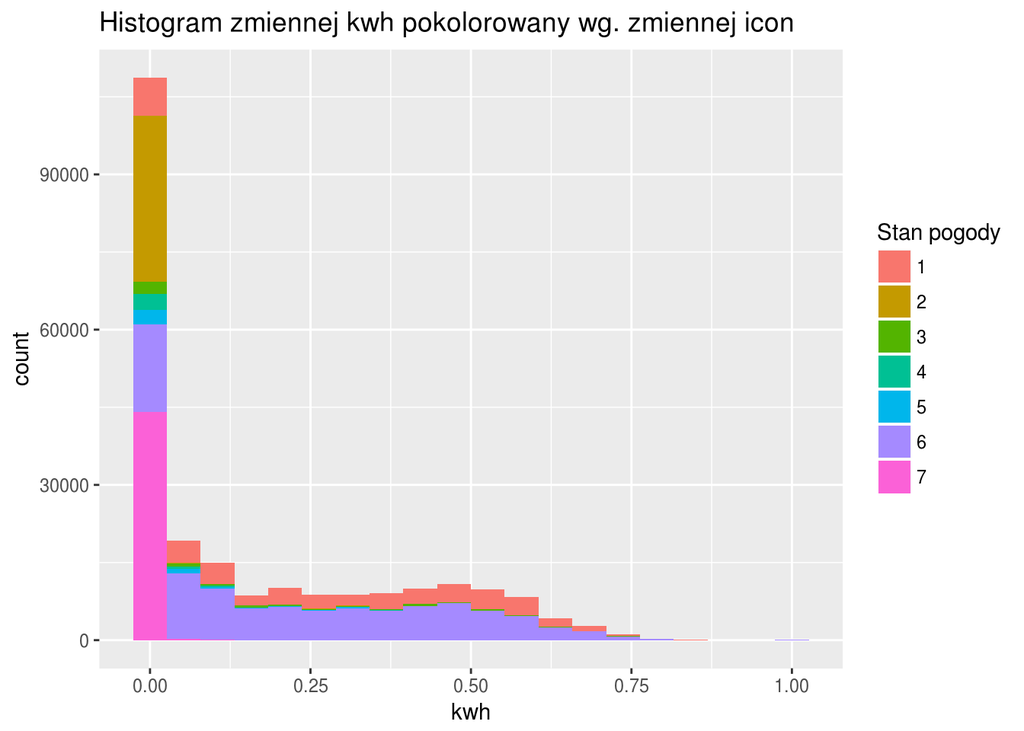

*Wykres 1. Histogram zmiennej *kwh* pokolorowany według zmiennej *icon*. Łatwo zauważyć, że niektóre stany pogody występują wyłącznie przy niskiej wartości produkcji energii - prawdopodobnie mogą oznaczać noc albo wysokie zachmurzenie.*

|  | min | max |
| --- | --- | --- |
| temperatura_ambiente | 0.045 | 0.818 |
| irr_pvgis_mod | 0.000 | 1.000 |
| irradiamento | 0.000 | 0.710 |
| pressure | 0.000 | 0.769 |
| windspeed | 0.000 | 0.696 |
| humidity | 0.16 | 1.00 |
| dewpoint | 0.139 | 0.865 |
| windbearing | 0.000 | 0.769 |
| cloudcover | 0.00 | 1.00 |
| icon | 0.000 | 0.750 |

## Lokalizacja, azymut i wysokość bezwzględna

Oprócz standardowych właściwości takich jak długość (*lon*) i szerokość (*lat*) mamy tutaj rzadziej spotykane atrybuty przydatne w lokalizowaniu miejsca działania każdego z czujników. Zmienna *azimuth* określa tzw. azymut, czyli kąt między pomiędzy południkiem a wskazanym kierunkiem poziomym, z kolei *altitude* to zwyczajna wysokość bezględna określająca wysokość nad poziomem morza. Oba atrybuty pozwalają na ustalenie pozycji słońca względem czujnika.

|  | min | max |
| --- | --- | --- |
| lat | 0.415 | 0.553 |
| lon | 0.154 | 0.691 |
| altitude | 0.111 | 0.884 |
| azimuth | 0.128 | 0.818 |

## Wektor PCNM

Nazwa atrybutów w tej grupie wskazuje na ich występowanie jako argumenty algorytmu analizy współrzędnych głównych macierzy sąsiedztwa (ang. *principal coordinate analysis of neighbour*, w skrócie *PCNM*). Technika ta umożliwia rozwiązanie problemu autokorelacji przestrzennej wywołanej bliskością czujników, co jest niepożądane w przypadku tworzenia modelu predykcji produkcji energii. Przy takim założeniu wartości atrybutu stanowią tzw. wektory własne opisujące przestrzeń, obliczone na podstawie macierzy odległości między panelami.

|  | min | max |
| --- | --- | --- |
| pcnm1 | 0.000 | 1.000 |
| pcnm2 | 0.000 | 0.972 |
| pcnm3 | 0.000 | 1.000 |
| pcnm4 | 0.000 | 1.000 |
| pcnm5 | 0.000 | 1.000 |
| pcnm6 | 0.000 | 1.000 |
| pcnm7 | 0.000 | 1.000 |
| pcnm8 | 0.000 | 1.000 |
| pcnm9 | 0.000 | 1.000 |
| pcnm10 | 0.000 | 1.000 |
| pcnm11 | 0.000 | 1.000 |
| pcnm12 | 0.000 | 1.000 |
| pcnm13 | 0.137 | 1.000 |
| pcnm14 | 0.000 | 1.000 |
| pcnm15 | 0.000 | 1.000 |

## LISA

Ta grupa atrybutów zawiera atrybuty podobne do tych z danych pogodowych oraz lokalizacji (oprócz właściwości *icon*), jednak z dodatkowym oznaczeniem *i*. Litera ta, przy jednoczesnym występowaniu wektora PCNM, może wskazywać na użycie algorytmu LISA (ang. *Local Indicator of Spatial Association*) obliczające na podstawie wektora własnego PCNM lokalne statystyki, wolne od problemu autokorelacji przestrzennej.

|  | min | max |
| --- | --- | --- |
| tempi | 0.009 | 0.983 |
| irri | 0.108 | 1.000 |
| pressurei | 0.000 | 1.000 |
| windspeedi | 0.000 | 1.000 |
| humidityi | 0.034 | 0.579 |
| dewpointi | 0.063 | 0.415 |
| windbearingi | 0.000 | 1.000 |
| cloudcoveri | 0.000 | 1.000 |
| altitudei | 0.000 | 0.982 |
| azimuthi | 0.000 | 1.000 |
| irri_pvgis_mod | -0.001 | 1.006 |

## Ilość energii wytworzonej oraz *dist*

Ostatnim atrybutem jest zmienna wskazująca na ilość wytworzonej energii. Nie wiadomo jednak, czy jest to wartość pochodząca z czujnika, czy wartość wyliczona na podstawie modelu predykcji, na co wskazują inne kolumny występujace w zbiorze (wtedy zbiór możnaby określić zbiorem uczącym np. sieć neuronową). Opcja druga jest bardziej prawdopodobna, jeżeli spojrzymy na zmienną *dist* - ponieważ wartość ta ma dużo większą dokładność niż pozostałe atrybuty w zbiorze, prawdopodobnie jest obliczana na podstawie danych z tego zbioru. Najprawdopodobnie więc wartość jest formą jakiejś statystyki wykorzystywanej przez model predykcji, zwiększającej jakość predykcji.

|  | min | max |
| --- | --- | --- |
| dist | 0.000000000 | 1.000000000 |
| kwh | 0.000 | 1.000 |

# Przygotowanie danych

W trakcie testów okazało się, że w wielu przypadkach wystepowały wartości zerowe na atrybutach potencjalne ważnych dla późniejszej analizy i tworzenia regresora - mowa tu mianowicie o atrybutach *kwh* oraz *irradiamento* (naświetlenie). Aby zapewnić, że analiza przebiegnie prawidłowo, brakujące wartości należało uzupełnić.

Kwestia ta była o tyle trudniejsza, że wartości zerowe na właściwości *kwh* wcale nie musiały być błędne - mogły wynikać z faktu, że ilość światła była zbyt mała, aby wyprodukować jakąkolwiek energię (np. w nocy). W związku z tym należało przyjąć następującą metodologię:

1. Jeżeli wartość *kwh* jest niezerowa, należy ją zostawić w spokoju.
2. Jeżeli wartosć *kwh* jest zerowa, należy wyliczyć średnią dla danego czujnika w ciągu danego miesiąca o danej godzinie i umieścić ją w atrybucie *kwh*.

Oddzielną kwestią jest zmienna określająca naświetlenie - czasem okazywało się, że mimo zerowego naświetlenia istniała dodatnia wartość *kwh*. W tym przypadku zastosowano nieco podobną metodologię do poprzedniej:

1. Jeżeli wartość *irradiamento* jest niezerowa, należy ją zostawić w spokoju.
2. Jeżeli wartosć *irradiamento* jest zerowa, należy wyliczyć średnią dla danego czujnika w ciągu danego roku i miesiąca, a następnie umieścić ją w atrybucie *irradiamento*

# Korelacja między zmiennymi

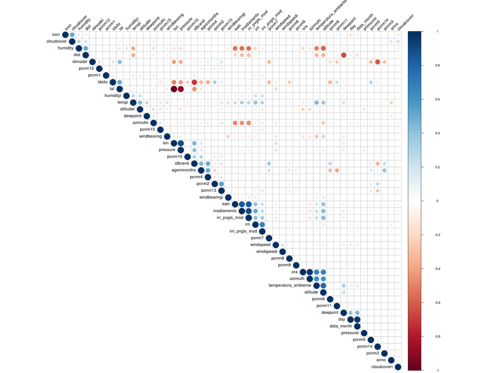

*Wykres 2. Korelacja między zmiennymi (bez zmiennej daty).*

W oparciu o powyższy wykres można zauważyć następujące związki:

# Wykres wytwarzania energii w zależności od czasu i lokalizacji czujnika

[video not shown]

*Wykres 3. Animowany wykres wytwarzania energii dla 2012 i 2013 roku (kliknij, aby przerwać animację)*

Powyższy wykres przedstawia sumę wyprodukowanej energii w ciągu miesiąca przez każdy z zainstalowanych paneli. Na jego podstawie można dojść do ciekawych wniosków:

- Na wykresie z roku 2012 *panel nr 10* wykazuje dużą produkcję energii w stosunku do reszty paneli. Jeżeli przyjrzeć się dokładniej, od sierpnia sumy wyprodukowanej energii są identyczne dla parzystych, jak i nieparzystych miesięcy oraz tworzą tzw. “zygzak”. Ponieważ trudno wyjaśnić ten fakt naukowo, wygląda na to, że dane dla tego panelu zostały sfałszowane.
- W roku 2013 *panel nr 15* w sierpniu uległ prawdopodobnie uszkodzeniu, przez co nie wytwarzał energii. Wykres od września dla tego panelu wygląda już prawidłowo.
- W tym samym roku kolejne panele mają sporo wyższy poziom produkcji energii w stosunku do reszty (uwaga ta dotyczy czujników nr 5, 6, 7 oraz ponownie 10). Również w tym przypadku tworzy się znajomy “zygzak”, przez co zachodzi podejrzenie sfałszowanej próbki.

# Schemat modelu uczenia oraz regresor

Jako model został użyty schemat *10-fold cross-validation + holdout*. Polega on na podzieleniu zbioru na dwa zbiory: uczący (80% próbek) oraz testowy (20% próbek), a następnie podzielenie zbioru uczącego wg. powtórzonej walidacji krzyżowej. Zbiór ten dzielony jest na 10 podzbiorów. Następnie następuje 10 tur analizy, podczas której każdy z podzbiorów w swojej turze staje się zbiorem walidującym, a pozostałe - uczącym. Dodatkowo dokonano optymalizacji parametrów - zastosowano dodatkowe skalowanie i centrowanie danych (co zmniejszało błąd średniokwadratowy, szczególnie w przypadku *Partial Least Squares*)

Do porównania zostały wybrane następujące algorytmy regresji:

- Linear Regression
- Stochastic Gradient Boosting
- Partial Least Squares

Przed stworzeniem regresora należało wyciąć ze zbioru próbki, które mogłyby potencjalnie zakłócić budowanie regresora. Dlatego też ze zbioru zostały usunięte wszystkie dane dotyczące paneli, których czujniki wykazywały nadmiernie optymistyczne wskazania w stosunku do reszty (opisane w poprzednim rozdziale).

|  | RMSE |
| --- | --- |
| PLS | 0.1238478 |
| LM | 0.0971827 |
| GBM | 0.0775281 |

Z powyższych modeli najlepszym okazał się ten wykorzystujący *Stochastic Gradient Boosting* - osiągnął najmniejszy błąd średniokwadratowy spośród wszystkich wykorzystanych algorytmów. Okupione jest to niestety znacznie dłuższym czasem obliczeń.

Należy pamiętać, że powyższe algorytmy wykorzystują regresję liniową. Istnieje wiele innych algorytmów wykorzystujący drzewa (np. *Random Forest*), a także sieci neuronowe (*Feed Forward Neural Network*), które w praktyce często okazują się lepsze niż te wykorzystujące regresję.

# Ważność atrybutów dla modelu SGB

```
## gbm variable importance
##
##   only 20 most important variables shown (out of 65)
##
##                 Overall
## irr_pvgis_mod  100.0000
## irradiamento    98.6617
## irri_pvgis_mod  11.0877
## irri             4.6370
## azimuthi         4.5796
## humidity         3.4613
## ora              2.9002
## cloudcover       1.8600
## data             1.7721
## icon             1.2681
## dist             1.0380
## idbrand          0.8924
## idmodel          0.8622
## pcnm7            0.6034
## anno             0.3786
## day              0.2732
## ageinmonths      0.2673
## lon              0.2193
## azimuth          0.1901
## altitude         0.1698
```